# 医学图像处理大作业 － 医学图像分割

## 余楚璇 14171056

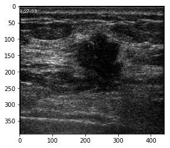

```python
import cv2
import numpy as np
import matplotlib.pyplot as plt
%pylab inline

img_init = cv2.imread('./data/WechatIMG2118.jpeg')
img_gray = cv2.cvtColor(img_init, cv2.COLOR_BGR2GRAY)

plt.imshow(img_gray, cmap='gray')
```

通过对图片的观察，可以发现图像的噪声较大，可以使用中值滤波或者高斯滤波的方法进行一定程度的抑制

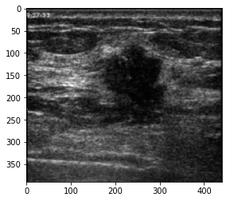

```python
# img2 = cv2.medianBlur(img_gray, 5)
# 高斯滤波
img2 = cv2.GaussianBlur(img_gray,(5,5),0)
plt.imshow(img2, cmap='gray')
```

观察到，在肿瘤区域的图像整体呈现最深的黑色，并且是一块很大的联通区域，可以使用阈值化再结合边界提取来提取

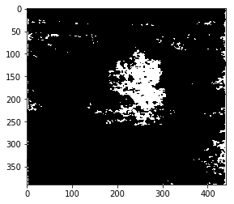

```python
# 通过直观观察可以使用阈值化的方法提取出目标区域
rst, img3 = cv2.threshold(img2, 12, 255, cv2.THRESH_BINARY_INV)
# img2 = cv2.medianBlur(img3, 3)
plt.imshow(img3,cmap='gray')
```

阈值化后的结果有很多的散点，这些多为噪声，可以用形态学方法进行去除，使用开操作（先腐蚀再膨胀）

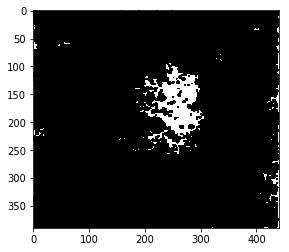

```python
# 腐蚀操作
kernel = np.ones((3,3),np.uint8)
erosion = cv2.erode(img3,kernel,iterations = 1)
plt.imshow(erosion,cmap='gray')
```

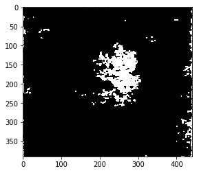

```python
# 膨胀操作
kernel2 = np.ones((3,3),np.uint8)
dilation = cv2.dilate(erosion,kernel,iterations = 1)
plt.imshow(dilation,cmap='gray')
```

在此基础上，肿瘤区域已经较为明显的提取出来了，使用图像区域外轮廓提取的方式，找出上图的最大外轮廓，即为可能目标轮廓

```python
# 提取上图中所有联通区域的轮廓
image, contours, hierarchy = cv2.findContours(dilation ,cv2.RETR_TREE,cv2.CHAIN_APPROX_SIMPLE)
```

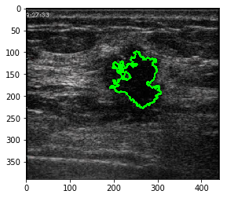

```python
# 找出最大轮廓并输出
max_a = 0;
max_id = -1;
for i in range(len(contours)) :
#     print cv2.contourArea(contours[i])
    if cv2.contourArea(contours[i]) > max_a :
        max_a = cv2.contourArea(contours[i])
        max_id = i
img_cont = cv2.drawContours(img_init, contours, max_id, (0,255,0), 3)
plt.imshow(img_cont)
```

# 方案2

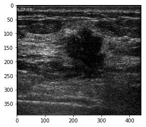

```python
# 函数库引入和图片读入
import cv2
import numpy as np
import matplotlib.pyplot as plt
img_in_2 = cv2.imread('./data/WechatIMG2118.jpeg')
img_in_gray = cv2.cvtColor(img_in_2, cv2.COLOR_BGR2GRAY)
plt.imshow(img_in_gray, cmap = 'gray')
```

观察图中的结构，可以发现，非目标区域有很多类似于散斑的噪声，这些构成了许多的纹理结构，这些纹理可以由**边缘提取**突出，而目标区域则纹理较少，因此提取结果应几乎没有变化。

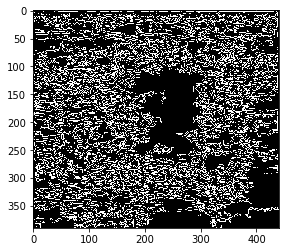

```python
# 边缘提取，取较小的最小阈值，增加纹理的捕捉情况
edges = cv2.Canny(img_in_gray,4,220)
plt.imshow(edges, cmap = 'gray')
```

可以看到，除了目标区域外，充满了由细小边缘充斥的图像。可以使用膨胀的方法，是小边缘扩张，使外界连成一片，即可对目标区域进行提取。

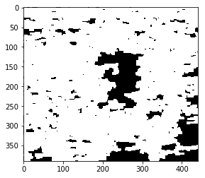

```python
# 膨胀
kernel_dilate = np.ones((6,6),np.uint8)
dilation = cv2.dilate(edges,kernel_dilate ,iterations = 1)

plt.imshow(dilation, cmap = 'gray')
```

通过膨胀后，边缘纹理联通在一起，中心的肿瘤区域，更加清晰，为了处理方便，进行反色，将目标区域作为高灰度区域，进行开操作，并得到最终结果

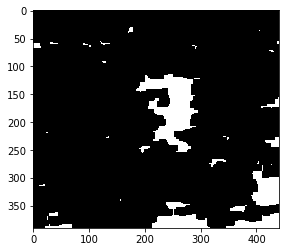

```python
# 反色并进行腐蚀
rst, dilation_INV = cv2.threshold(dilation, 11, 255, cv2.THRESH_BINARY_INV)
kernel_erode = np.ones((6,6),np.uint8)
erosion = cv2.erode(dilation_INV, kernel_erode, iterations = 1)
# kernel_dilate = np.ones((6,6),np.uint8)
# dilation = cv2.dilate(erosion ,kernel_dilate ,iterations = 1)

plt.imshow(erosion, cmap = 'gray')
```

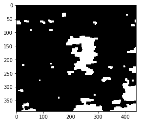

```python
# 膨胀
kernel_dilate = np.ones((6,6),np.uint8)
dilation = cv2.dilate(erosion ,kernel_dilate ,iterations = 1)
plt.imshow(dilation, cmap = 'gray')
```

```python
# 外轮廓提取
image, contours, hierarchy = cv2.findContours(dilation ,cv2.RETR_TREE,cv2.CHAIN_APPROX_SIMPLE)
```

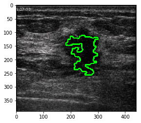

```python
# 最大外轮廓
max_a = 0;
max_id = -1;
for i in range(len(contours)) :
    if cv2.contourArea(contours[i]) > max_a :
        max_a = cv2.contourArea(contours[i])
        max_id = i
img_cont2 = cv2.drawContours(img_in_2, contours, max_id, (0,255,0), 3)
plt.imshow(img_cont2)
```

# 方案3